# Opportunities for integration through homeownership and their correlation with education level and employment rate

# 4 What are the ownership types for different nationalities?

```r
home_owner_data <- merged_data %>% select(SECCITIZENSHIP, TYPEOFOWNERSHIP,
    SIZEOFPRIVATEHOUSEHOLD, NATIONALITYCAT, NATIONALITYCONTI
  )
```

**Decoding Data**

```r
home_owner_data <- home_owner_data %>%
  filter(
    !is.na(NATIONALITYCAT),
    !is.na(SIZEOFPRIVATEHOUSEHOLD),
    !is.na(TYPEOFOWNERSHIP)
  )
```

```r
# Define homeownership (Owner vs. Renter)
home_owner_data <- home_owner_data %>%
  mutate(HOMEOWNERSHIP = case_when(
    TYPEOFOWNERSHIP %in% c("Condominium owner", "House owner") ~ "Owner",
    TYPEOFOWNERSHIP %in% c("Tenant", "Other situation") ~ "Renter",
    TRUE ~ NA_character_
  ))

home_owner_data <- home_owner_data %>%
    filter(
    !is.na(HOMEOWNERSHIP)
  )
```

**Group household size**

```r
home_owner_data <- home_owner_data %>%
  mutate(
    SIZEOFPRIVATEHOUSEHOLD_GROUP = case_when(
      SIZEOFPRIVATEHOUSEHOLD == 1 ~ "1 member",
      SIZEOFPRIVATEHOUSEHOLD >= 2 & SIZEOFPRIVATEHOUSEHOLD <= 3 ~ "2-3 members",
      SIZEOFPRIVATEHOUSEHOLD >= 4 ~ "4+ members",
      TRUE ~ NA_character_
    )
  ) %>%
  filter(!is.na(SIZEOFPRIVATEHOUSEHOLD_GROUP))
```

## 4.1 Plots

### 4.1.1 Do local Swiss people tend to own a house more than foreigners?

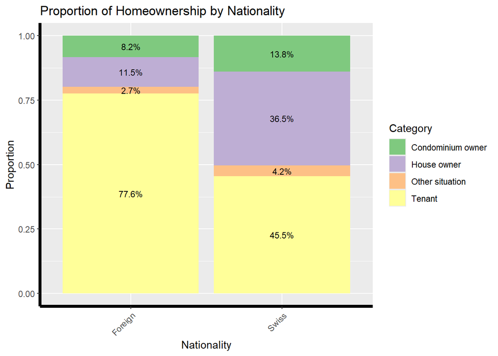

```r
plot1 <- create_proportional_plot(
  data = home_owner_data,
  group_var = "NATIONALITYCAT",
  fill_var = "TYPEOFOWNERSHIP",
  y_var = "proportion",
  title = "Proportion of Homeownership by Nationality",
  x_label = "Nationality",
  y_label = "Proportion"
)
print(plot1)
```

**From this chart, we can understand that local Swiss people tend to have a significantly higher rate of homeownership compared to foreigners. Specifically, Swiss individuals are more likely to own a house or a condominium/apartment (50.3% ownership), while foreigners overwhelmingly tend to rent (77.6%). This indicates a clear difference in housing patterns between Swiss nationals and foreigners.**

### 4.1.2 What is the distribution of homeownership types by continent of nationality (excluding Switzerland, stateless individuals)?

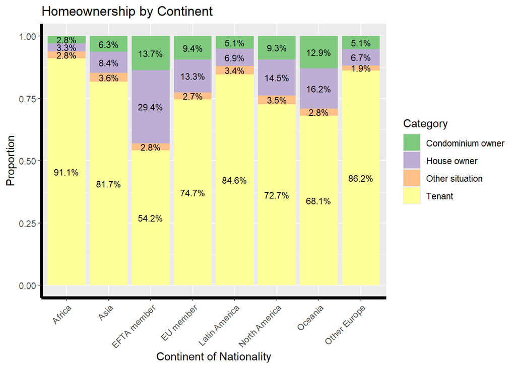

```r
# 8.2 Example: Proportions by Continent of Nationality and Ownership
plot2 <- create_proportional_plot(
  data = home_owner_data %>%
    filter(
      !(NATIONALITYCONTI %in% c("Switzerland", NA, "Stateless"))
    ),
  group_var = "NATIONALITYCONTI",
  fill_var = "TYPEOFOWNERSHIP",
  y_var = "proportion",
  title = "Homeownership by Continent",
  x_label = "Continent of Nationality",
  y_label = "Proportion"
)
print(plot2)
```

### 4.1.3 What is the proportion of different ownership statuses for people who had or did not have more than one passport?

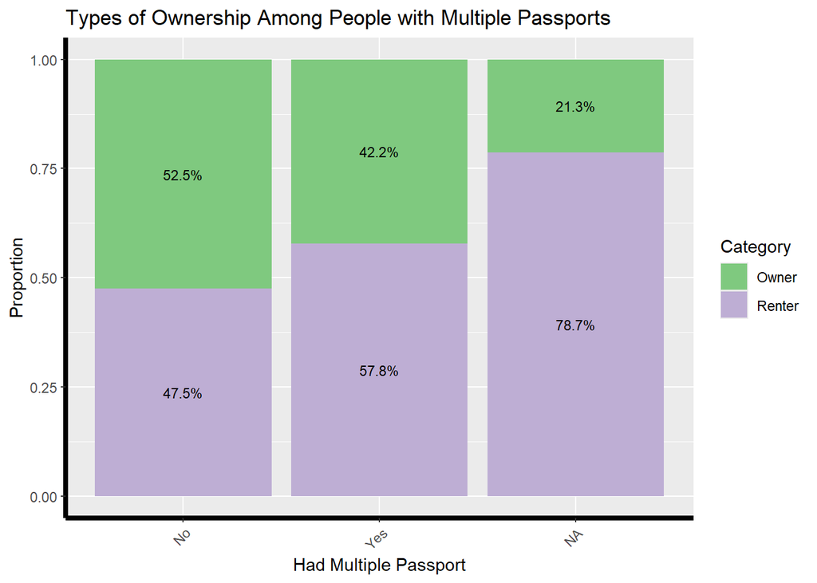

```r
# 8.3 Plot: Proportion of Homeownership by Citizenship
plot1 <- create_proportional_plot(
  data = home_owner_data,
  group_var = "SECCITIZENSHIP",
  fill_var = "HOMEOWNERSHIP",
  y_var = "proportion",
  title = "Types of Ownership Among People with Multiple Passports",
  x_label = "Had Multiple Passport",
  y_label = "Proportion"
)
print(plot1)
```

### 4.1.4 How does homeownership differ by nationality and household size?

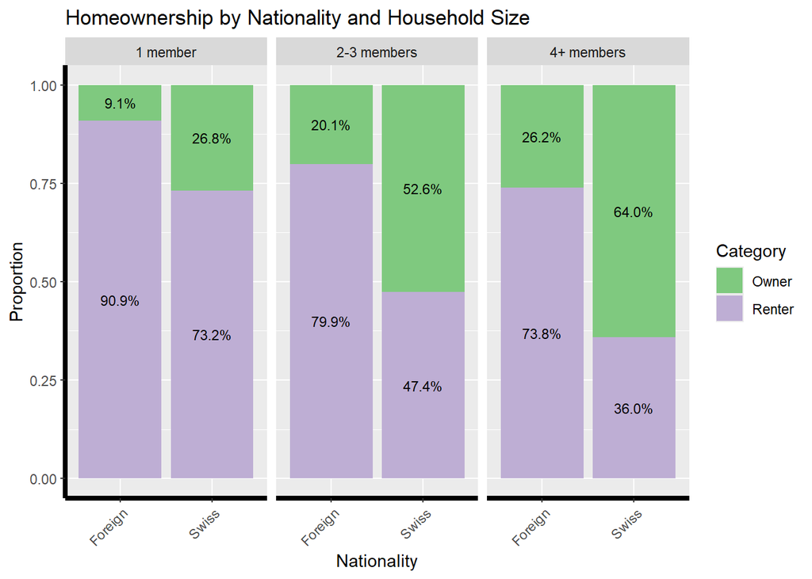

```r
# 8.4 Example of summarizing by household size
plot3 <- create_proportional_plot(
  data = home_owner_data,
  group_var = "NATIONALITYCAT",
  fill_var = "HOMEOWNERSHIP",
  y_var = "proportion",
  title = "Homeownership by Nationality and Household Size",
  x_label = "Nationality",
  y_label = "Proportion",
  facet_var = "SIZEOFPRIVATEHOUSEHOLD_GROUP"
)
print(plot3)
```

**People with larger families tend to own a house more often, both among locals and foreigners.**

## 4.2 Answer to question

**Recommendations**

- Policy Support for Foreign Residents: Implement targeted housing policies to facilitate foreign residents’ access to home ownership, addressing financial and legal barriers.
- Encourage home ownership Among Larger Families: Provide incentives or assistance to larger families, who demonstrate a greater propensity to own homes.

# 5 How Does Nationality Impact Workload?

**Selecting Variables for Chart Building**

```r
work_loading_data <- merged_data %>% select(RENTNET,NATIONALITYCAT,TIMEWORKEDPERWEEKSUM, RESIDENTPERMIT)
```

**Filtering Extreme High RENTNET Values and NA**

```r
work_loading_data <- work_loading_data %>% filter((RENTNET < 5000 | RENTNET == -8) &
                                            !is.na(NATIONALITYCAT) &
                                            !is.na(RESIDENTPERMIT) &
                                            TIMEWORKEDPERWEEKSUM >= 0)
```

## 5.1 Plots

### 5.1.1 Nationality Distribution

**What is the distribution of the population by nationality?**

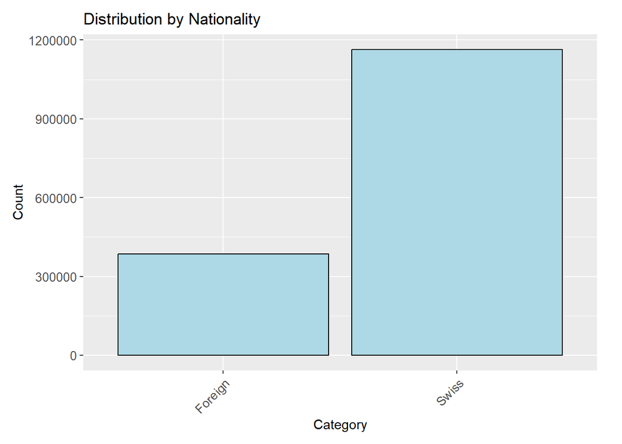

```r
distribution_categorical(work_loading_data, NATIONALITYCAT, "Nationality")
```

**The chart shows Swiss residents outnumber foreign nationals, but the significant foreign population cannot be ignored.**

### 5.1.2 Analysis of Working Hours

**General overview work time between Swiss and foreign people**

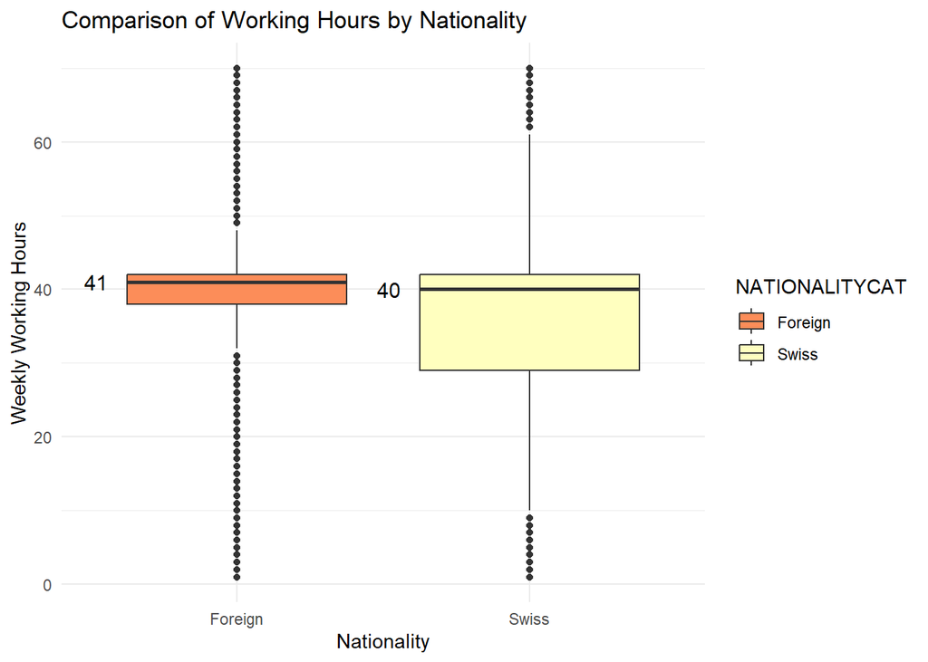

```r
summary_stats <- work_loading_data %>%
  group_by(NATIONALITYCAT) %>%
  summarise(
    mean_hours = mean(TIMEWORKEDPERWEEKSUM, na.rm = TRUE),
    median_hours = median(TIMEWORKEDPERWEEKSUM, na.rm = TRUE),
    sd_hours = sd(TIMEWORKEDPERWEEKSUM, na.rm = TRUE),
    min_hours = min(TIMEWORKEDPERWEEKSUM, na.rm = TRUE),
    max_hours = max(TIMEWORKEDPERWEEKSUM, na.rm = TRUE),
    Q1 = quantile(TIMEWORKEDPERWEEKSUM, probs = 0.25, na.rm = TRUE),
    Q3 = quantile(TIMEWORKEDPERWEEKSUM, probs = 0.75, na.rm = TRUE),
    count = n()
  )

work_loading_data %>%
  filter(!is.na(TIMEWORKEDPERWEEKSUM) & !is.na(NATIONALITYCAT)) %>%
  group_by(NATIONALITYCAT) %>%
  ggplot(aes(x = NATIONALITYCAT, y = TIMEWORKEDPERWEEKSUM, fill = NATIONALITYCAT)) +
  geom_boxplot() +
  scale_fill_brewer(palette = "Spectral")+
  stat_summary(
    fun = median,
    geom = "text",
    aes(label = round(..y.., 1)),
    vjust = 0.5,
    hjust = 6.5,
    color = "black",
    size = 4
  ) +
  labs(
    title = "Comparison of Working Hours by Nationality",
    x = "Nationality",
    y = "Weekly Working Hours"
  ) +
  theme_minimal()
```

```r
print(summary_stats)
```

```
## # A tibble: 2 × 9
##   NATIONALITYCAT mean_hours median_hours sd_hours min_hours max_hours    Q1
##   <fct>               <dbl>        <dbl>    <dbl>     <int>     <int> <dbl>
## 1 Foreign              37.8           41     10.8         1        70    38
## 2 Swiss                35.6           40     12.6         1        70    29
## # ℹ 2 more variables: Q3 <dbl>, count <int>
```

**1. Median Weekly Working Hours** - **Migrants (Foreign):** Median weekly working time is 41 hours.  
- **Swiss Residents:** Median weekly working time is 40 hours.  
- **Implication:** This small difference aligns with the hypothesis that migrants might work slightly more on average to meet economic demands.

**2. Mean Weekly Working Hours** - **Migrants (Foreign):** Average working hours is 37.85.  
- **Swiss Residents:** Average working hours is 35.61.  
- **Implication:** This supports the idea that migrants tend to work longer hours overall, potentially reflecting the economic disparity between the groups.

**3. Spread and Variability** - **Standard Deviation:**  
- Migrants: 10.76, indicating more consistent working schedules.  
- Swiss Residents: 12.63, showing greater variability in working hours.  
- **First Quarterly (Q1):**  
- Migrants: 38 hours, reflecting a larger proportion working full-time or near full-time hours.  
- Swiss Residents: 29 hours, suggesting more part-time or flexible schedules among locals.

### 5.1.3 Rent Analysis from a Financial Perspective

**What is the difference in renting prices between foreigners and locals?**

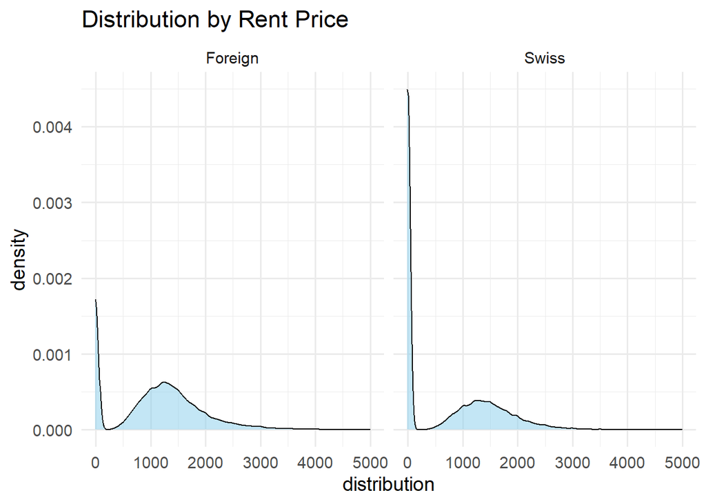

```r
work_loading_data %>%
  distribution_numeric(RENTNET, "Rent Price")
```

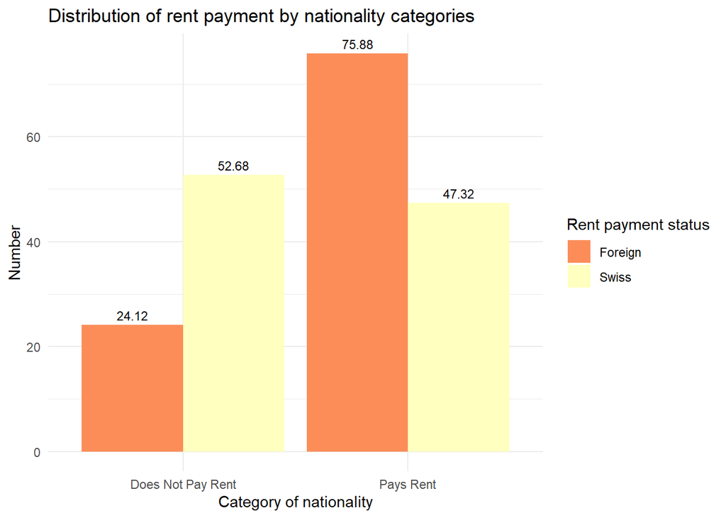

```r
rent_analysis <- work_loading_data %>%
  filter(!is.na(NATIONALITYCAT)) %>%
  mutate(
    pays_rent = case_when(
      RENTNET > 0 ~ "Pays Rent",
      RENTNET < 1 | is.na(RENTNET) ~ "Does Not Pay Rent"
    )
  ) %>%
  group_by(NATIONALITYCAT, pays_rent) %>%
  summarise(count = n(), .groups = "drop") %>%
  group_by(NATIONALITYCAT) %>%
  mutate(percentage = round(count / sum(count) * 100,2)) %>%
  ungroup()

ggplot(rent_analysis, aes(x = pays_rent, y = percentage, fill = NATIONALITYCAT)) +
  geom_bar(stat = "identity", position = "dodge") +
  geom_text(
    aes(label = round(percentage, 2)),
    position = position_dodge(width = 0.9),
    vjust = -0.5,
    size = 3
  ) +
  scale_fill_brewer(palette = "Spectral")+
  labs(title = "Distribution of rent payment by nationality categories",
       x = "Category of nationality",
       y = "Number",
       fill = "Rent payment status") +
  theme_minimal()
```

```r
print(rent_analysis)
```

```
## # A tibble: 4 × 4
##   NATIONALITYCAT pays_rent          count percentage
##   <fct>          <chr>              <int>      <dbl>
## 1 Foreign        Does Not Pay Rent  92944       24.1
## 2 Foreign        Pays Rent         292464       75.9
## 3 Swiss          Does Not Pay Rent 613260       52.7
## 4 Swiss          Pays Rent         550954       47.3
```

- Swiss residents are more likely not to pay rent, which might indicate higher rates of home ownership or alternative living arrangements among locals.